# Taller Evaluado

Herramientas Computacionales

07 August, 2020

## Taller Evaluado

La base de datos `Peliculas.csv` contiene información de 3.807 películas norteamericanas que fueron calificadas en la escala de IMDB (Internet Movie Database). Además, cuenta con diferentes variables relacionadas con el año de estreno, director, actores principales, etc. El objetivo de este estudio es analizar los factores que pueden influir en que una película sea bien calificada. Cargue la base de datos y desarrolle las siguientes preguntas.

```r
library(tidyverse)
df <- readr::read_csv("Peliculas.csv")
```

### Pregunta 1

Use las herramientas de dplyr para crear un nuevo data frame (`df`):

- Con las siguientes variables: nombre de la película, nombre del director, nombre primer actor, número de críticas positivas, duración, cantidad bruta recaudada, lenguaje, presupuesto, año, puntuación IMDB, likes de la película y género predominante.
- Elimine del `df` todas las observaciones que tengan alguna casilla vacía.
- Ordénelo por año, del más reciente al más antiguo.

Con este `df` desarrolle las preguntas que siguen.

> **Solución:**

```r
## Seleccion de variables
df <- df %>%
  dplyr::select(Nombre_Pelicula,
                Nombre_Director,
                Nombre_Primer_Actor,
                Criticas_Positivas,
                Duracion,
                Cantidad_Bruta_Recaudada,
                Lenguaje,
                Presupuesto,
                Año,
                Puntuacion_IMDB,
                Likes_Pelicula,
                Genero_Predominante)

## Eliminacion de missing
df <- df %>% na.omit()

## Ordenar la base por año
df <- df %>% arrange(desc(Año))

## Visualicemos la base
## la funcion scroll_box crea una caja dinamica y de mejor estetica.
kableExtra::scroll_box(knitr::kable(head(df)), height = 2, fixed_thead = list(enabled = T/F, background = "anycolor"))
```

| Nombre_Pelicula | Nombre_Director | Nombre_Primer_Actor | Criticas_Positivas | Duracion | Cantidad_Bruta_Recaudada | Lenguaje | Presupuesto | Año | Puntuacion_IMDB | Likes_Pelicula | Genero_Predominante |
| --- | --- | --- | --- | --- | --- | --- | --- | --- | --- | --- | --- |
| Batman v Superman: Dawn of Justice | Zack Snyder | Henry Cavill | 70 | 183 | 330249062 | English | 2.50e+08 | 2016 | 6 , 9 puntos | 197000 | Action |
| Captain America: Civil War | Anthony Russo | Robert Downey Jr. | 80 | 147 | 407197282 | English | 2.50e+08 | 2016 | 8 , 2 puntos | 72000 | Action |
| Star Trek Beyond | Justin Lin | Sofia Boutella | 70 | 122 | 130468626 | English | 1.85e+08 | 2016 | 7 , 5 puntos | 30000 | Action |
| The Legend of Tarzan | David Yates | Christoph Waltz | 60 | 110 | 124051759 | English | 1.80e+08 | 2016 | 6 , 6 puntos | 29000 | Action |
| X-Men: Apocalypse | Bryan Singer | Jennifer Lawrence | 70 | 144 | 154985087 | English | 1.78e+08 | 2016 | 7 , 3 puntos | 54000 | Action |
| Suicide Squad | David Ayer | Will Smith | 60 | 123 | 161087183 | English | 1.75e+08 | 2016 | 6 , 9 puntos | 80000 | Action |

### Pregunta 2

Como interesa estudiar la puntuación de la película, debe transformar la variable `Puntuacion_IMDB`, ya que esta cuenta con un formato no numérico. Cree una variable llamada `Puntuacion` que tome solo la puntuación en formato numérico a partir de `Puntuacion_IMDB`. Luego, construya el objeto `prom_puntuacion` que contenga la puntuación promedio para cada tipo de género predominante.

> **Solución**:  
> Para hacer el cambio, es necesario primero eliminar la palabra *puntos*  
> y luego reemplazar *" , "* por *“.”*, ya que los decimales no son por coma. Finalmente, la variable al ser manipulada con `gsub()` debe ser transformada a número.

```r
df <- df %>%
  dplyr::mutate(Puntuacion = gsub("puntos", "", Puntuacion_IMDB),
                Puntuacion = gsub(" , ", ".", Puntuacion),
                Puntuacion = as.numeric(Puntuacion)
  )

## Visualicemos la base
## la funcion scroll_box crea una caja dinamica y de mejor estetica.
kableExtra::scroll_box(knitr::kable(head(df)), height = 2, fixed_thead = list(enabled = T/F, background = "anycolor"))
```

| Nombre_Pelicula | Nombre_Director | Nombre_Primer_Actor | Criticas_Positivas | Duracion | Cantidad_Bruta_Recaudada | Lenguaje | Presupuesto | Año | Puntuacion_IMDB | Likes_Pelicula | Genero_Predominante | Puntuacion |
| --- | --- | --- | --- | --- | --- | --- | --- | --- | --- | --- | --- | --- |
| Batman v Superman: Dawn of Justice | Zack Snyder | Henry Cavill | 70 | 183 | 330249062 | English | 2.50e+08 | 2016 | 6 , 9 puntos | 197000 | Action | 6.9 |
| Captain America: Civil War | Anthony Russo | Robert Downey Jr. | 80 | 147 | 407197282 | English | 2.50e+08 | 2016 | 8 , 2 puntos | 72000 | Action | 8.2 |
| Star Trek Beyond | Justin Lin | Sofia Boutella | 70 | 122 | 130468626 | English | 1.85e+08 | 2016 | 7 , 5 puntos | 30000 | Action | 7.5 |
| The Legend of Tarzan | David Yates | Christoph Waltz | 60 | 110 | 124051759 | English | 1.80e+08 | 2016 | 6 , 6 puntos | 29000 | Action | 6.6 |
| X-Men: Apocalypse | Bryan Singer | Jennifer Lawrence | 70 | 144 | 154985087 | English | 1.78e+08 | 2016 | 7 , 3 puntos | 54000 | Action | 7.3 |
| Suicide Squad | David Ayer | Will Smith | 60 | 123 | 161087183 | English | 1.75e+08 | 2016 | 6 , 9 puntos | 80000 | Action | 6.9 |

> Una vez creada la variable `Puntuacion`, calculamos el promedio por género predominante.

```r
prom_promedio <- df %>%
  dplyr::group_by(Genero_Predominante) %>%
  dplyr::summarise(Puntuacion = round(mean(Puntuacion, na.rm = TRUE), 2))

knitr::kable(prom_promedio)
```

| Genero_Predominante | Puntuacion |
| --- | --- |
| Action | 6.24 |
| Adventure | 6.50 |
| Animation | 6.66 |
| Biography | 7.11 |
| Comedy | 6.10 |
| Crime | 6.92 |
| Documentary | 6.78 |
| Drama | 6.72 |
| Family | 6.50 |
| Fantasy | 6.22 |
| Horror | 5.84 |
| Musical | 6.75 |
| Mystery | 6.78 |
| Romance | 6.65 |
| Sci-Fi | 6.66 |
| Thriller | 4.80 |
| Western | 5.70 |

### Pregunta 3

Use la librería ggplot2 para construir un gráfico de la distribución de la variable `Puntuacion` y un gráfico que permita comparar la distribución de la puntuación por género predominante. Comente.

> **Solución:** Un posible gráfico de distribución es el histograma. Para evaluar la distribución por categorías, una buena opción es el boxplot.

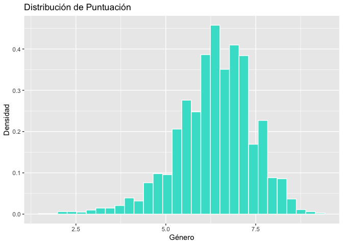

```r
ggplot(data = df, aes(x = Puntuacion, y = ..density..)) +
  geom_histogram(bins = 30, fill = "turquoise", color = "white") +
  xlab("Género") + ylab("Densidad") +
  ggtitle("Distribución de Puntuación")
```

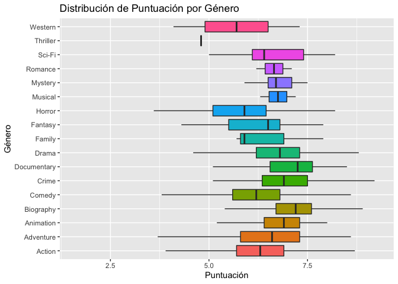

```r
ggplot(data = df, aes(x = Genero_Predominante, y = Puntuacion, fill = Genero_Predominante)) +
  geom_boxplot(outlier.shape = NA) +
  theme(legend.position = "none") +
  coord_flip() +
  xlab("Género") + ylab("Puntuación") +
  ggtitle("Distribución de Puntuación por Género")
```

> Podemos concluir que la puntuación tiene una leve asimetría hacia la izquierda. En cuanto a la distribución por género predominante, vemos que existen leves diferencias en la distribución de las puntuaciones, por lo tanto el género podría estar influyendo en la puntuación recibida por la película.

### Pregunta 4

Analice de manera gráfica la correlación de `Puntuacion` con el resto de las variables cuantitativas. Además, analice a través de una matriz gráfica, la dispersión y distribución de las variables.

> **Solución:**

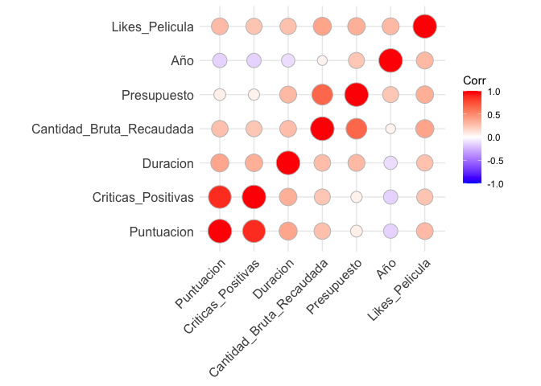

```r
df_cuanti <- df %>%
  dplyr::select(Puntuacion,
                Criticas_Positivas,
                Duracion,
                Cantidad_Bruta_Recaudada,
                Presupuesto,
                Año,
                Likes_Pelicula)

correlacion <- cor(df_cuanti)
ggcorrplot::ggcorrplot(correlacion, method = "circle")
```

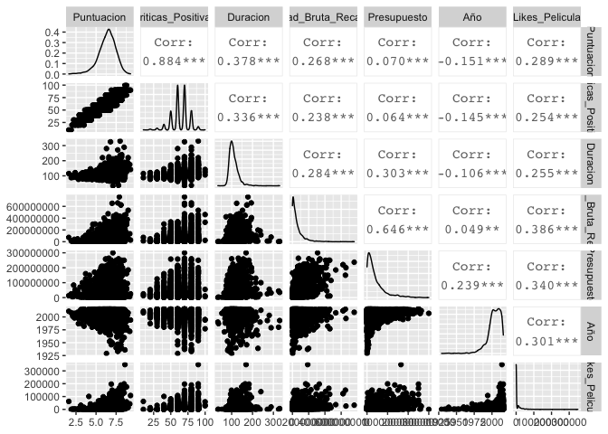

```r
options(scipen = 999)
GGally::ggpairs(df_cuanti)
```

> En función de la variable **Puntuacion**, las variables que más se relacionan con esta son `Criticas_Positivas` y `Duración`. Las dos presentan una relación directa. Mientras que la variable `Año` tiene una relación inversa, es decir, mientras más nueva sea la película, su puntaje tiende a ser menor.

### Pregunta 5

Ajuste un modelo de regresión lineal múltiple para predecir la puntuación en función de las variables Críticas Positivas, Duración y Género Predominante. Entregue un análisis simple de los residuos y comente si es un modelo adecuado. > **Solución**

```r
modelo <- lm(Puntuacion ~ Criticas_Positivas + Duracion + Genero_Predominante, data = df)

## Para hacer el summary(modelo)
## La funcion tidy de la libreria broom convierte el summary del modelo en un
## data.frame.

kableExtra::kable_styling(knitr::kable(broom::tidy(modelo)), font_size = 15)
```

| term | estimate | std.error | statistic | p.value |
| --- | --- | --- | --- | --- |
| (Intercept) | 1.2570240 | 0.0607957 | 20.6761918 | 0.0000000 |
| Criticas_Positivas | 0.0728634 | 0.0007777 | 93.6882985 | 0.0000000 |
| Duracion | 0.0038819 | 0.0004392 | 8.8380916 | 0.0000000 |
| Genero_PredominanteAdventure | 0.0627318 | 0.0331792 | 1.8906952 | 0.0587597 |
| Genero_PredominanteAnimation | 0.2139805 | 0.0816734 | 2.6199539 | 0.0088377 |
| Genero_PredominanteBiography | 0.2032408 | 0.0450333 | 4.5131223 | 0.0000066 |
| Genero_PredominanteComedy | -0.0036185 | 0.0243017 | -0.1489002 | 0.8816422 |
| Genero_PredominanteCrime | 0.1612556 | 0.0382637 | 4.2143192 | 0.0000258 |
| Genero_PredominanteDocumentary | 0.2127791 | 0.0868883 | 2.4488822 | 0.0143859 |
| Genero_PredominanteDrama | 0.1065712 | 0.0275573 | 3.8672611 | 0.0001124 |
| Genero_PredominanteFamily | -0.2650653 | 0.2775617 | -0.9549781 | 0.3396644 |
| Genero_PredominanteFantasy | 0.0935395 | 0.0879802 | 1.0631884 | 0.2877807 |
| Genero_PredominanteHorror | -0.0901199 | 0.0447108 | -2.0156174 | 0.0439275 |
| Genero_PredominanteMusical | 0.3492517 | 0.3396138 | 1.0283790 | 0.3038531 |
| Genero_PredominanteMystery | 0.1298856 | 0.1177488 | 1.1030742 | 0.2700819 |
| Genero_PredominanteRomance | 0.2803072 | 0.3396763 | 0.8252185 | 0.4093121 |
| Genero_PredominanteSci-Fi | 0.2082312 | 0.1821946 | 1.1429056 | 0.2531675 |
| Genero_PredominanteThriller | 0.2596561 | 0.4802173 | 0.5407053 | 0.5887502 |
| Genero_PredominanteWestern | -0.6677519 | 0.3396814 | -1.9658179 | 0.0494102 |

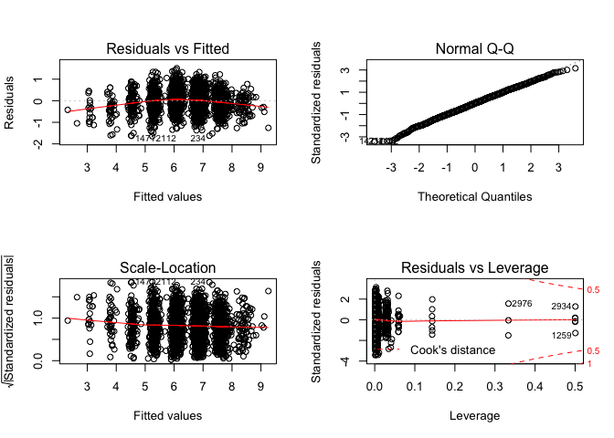

```r
par(mfrow = c(2, 2))
plot(modelo)
```

```r
knitr::kable(data.frame(R.cuadrado = round(summary(modelo)$adj.r.squared, 2),
                        Normalidad = round(nortest::lillie.test(modelo$residuals)$p.value, 2),
                        Homocedasticidad = round(lmtest::bptest(modelo)$p.value, 2),
                        Autocorrelacion = round(lmtest::dwtest(modelo)$p.value, 2)
                        )
             )
```

|  | R.cuadrado | Normalidad | Homocedasticidad | Autocorrelacion |
| --- | --- | --- | --- | --- |
| BP | 0.79 | 0.16 | 0 | 0.07 |

> La variables del modelo son significativas. Sin embargo, la variable `Genero` presenta algunas categorías que no son significativas, como por ejemplo, `Comedia`. En cuanto a los supuestos del modelo, se concluye que el modelo no es adecuado, ya que si bien los errores son normales y no autocorrelacionados, existe heterocedasticidad en los residuos.

### Pregunta 6

Cree una función que reciba el nombre del primer actor y retorne:

- Un listado de las películas donde participó como primer actor ordenadas por puntuación más alta.
- La cantidad de películas donde participó por género.
- Un gráfico de la frecuencia de los géneros donde participa.

Pruebe su función con el actor `Leonardo DiCaprio`.

> **Solución**:

```r
Historial_Actor <- function(actor) {

  ## Filtro de base segun actor.
  Tabla <- df %>%
    dplyr::filter(Nombre_Primer_Actor == actor)

  ## Rescatamos los nombres y puntuaciones de las peliculas donde participa.
  T1 <- Tabla %>%
    dplyr::select(Nombre_Pelicula, Puntuacion) %>%
    dplyr::arrange(desc(Puntuacion))

  ## Cuenta de peliculas segun genero predominante.
  T2 <- Tabla %>%
    dplyr::group_by(Genero_Predominante) %>%
    dplyr::count()

  ## Grafico de T2.
  Grafico <- ggplot(data = T2, aes(x = Genero_Predominante, y = n,
                                   fill = Genero_Predominante)) +
    geom_bar(position = "dodge", stat = "identity") +
    coord_flip() +
    theme(legend.position = "none") +
    geom_text(aes(label = n), position = position_dodge(width = 0.9),
              vjust = -0.25) +
    ylab("Frecuencia") + xlab("Género") +
    ggtitle(paste("Distribución de Géneros del Actor", actor))

  return(list(Peliculas = T1, Generos = T2, Grafico = Grafico))

}

### La funcion puede retornar 3 objetos: Peliculas, Generos o Graficos.
### Los llamamos por separado para visualizar de manera mas estetica.

kableExtra::kable_styling(knitr::kable(Historial_Actor("Leonardo DiCaprio")$Peliculas), font_size = 15)
```

| Nombre_Pelicula | Puntuacion |
| --- | --- |
| Inception | 8.8 |
| Django Unchained | 8.5 |
| The Departed | 8.5 |
| The Wolf of Wall Street | 8.2 |
| The Revenant | 8.1 |
| Shutter Island | 8.1 |
| Catch Me If You Can | 8.0 |
| Titanic | 7.7 |
| The Aviator | 7.5 |
| Gangs of New York | 7.5 |
| Revolutionary Road | 7.3 |
| Body of Lies | 7.1 |
| Romeo + Juliet | 6.8 |
| Marvin’s Room | 6.7 |
| J. Edgar | 6.6 |
| The Beach | 6.6 |
| The Man in the Iron Mask | 6.4 |

```r
kableExtra::kable_styling(knitr::kable(Historial_Actor("Leonardo DiCaprio")$Generos), font_size = 15)
```

| Genero_Predominante | n |
| --- | --- |
| Action | 3 |
| Adventure | 2 |
| Biography | 4 |
| Crime | 2 |
| Drama | 5 |
| Mystery | 1 |

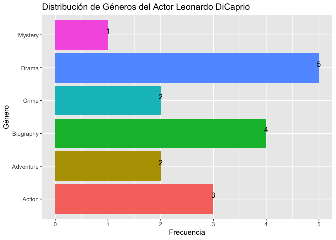

```r
Historial_Actor("Leonardo DiCaprio")$Grafico
```

### Pregunta 7

Reporte los ejercicios anteriores en `RMarkdown`.